# Coursera.EDA.Wk1.Assignment_1

MCCurcio

12/25/2020

# Coursera-EDA-Wk1-Assignment 1

This assignment uses data from the [UC Irvine Machine Learning Repository](http://archive.ics.uci.edu/ml/index.php).

We are using the [Individual household electric power consumption Data Set](https://archive.ics.uci.edu/ml/datasets/individual+household+electric+power+consumption)

**The 9 variables in the dataset are taken from the UCI web site:**

- Date, Time, Global_active_power, Global_reactive_power, Voltage, Global_intensity, Sub_metering_1, Sub_metering_2, Sub_metering_3

**Tasks**

1. Use GitHub material from Roger Peng.
   - Use: `git clone https://github.com/rdpeng/ExData_Plotting1`
2. Save to MCCurcio GitHub repository?
3. Produce 4 plots;
   1. Histogram of Global_active_power
   2. Plot of Global_active_power versus datetime
   3. Plot of Sub meterings versus datetime
   4. 2 x 2 Plots

## Data Preparation

### Load Household Power Consumption(hpc)

NOTE: The date column is read into `hpc` dataframe **with** date = *col_date(format = “%d/%m/%Y”)*. This makes subsetting data into Feb. 1 and 2 easier.

```r
library(readr)

setwd("~/Dropbox/R_exercises/Coursera/Exploratory Data Analysis/week1/ExData_Plotting1")

hpc <- read_delim("exdata_data_household_power_consumption.zip",
                  ";",
                  trim_ws = TRUE,
                  escape_double = FALSE,
                  col_types = cols(Date = col_date(format = "%d/%m/%Y"),
                                   Time = col_character(),
                                   Global_intensity = col_skip()))

str(hpc)
```

```
## tibble [2,075,259 × 8] (S3: spec_tbl_df/tbl_df/tbl/data.frame)
##  $ Date                 : Date[1:2075259], format: "2006-12-16" "2006-12-16" ...
##  $ Time                 : chr [1:2075259] "17:24:00" "17:25:00" "17:26:00" "17:27:00" ...
##  $ Global_active_power  : num [1:2075259] 4.22 5.36 5.37 5.39 3.67 ...
##  $ Global_reactive_power: num [1:2075259] 0.418 0.436 0.498 0.502 0.528 0.522 0.52 0.52 0.51 0.51 ...
##  $ Voltage              : num [1:2075259] 235 234 233 234 236 ...
##  $ Sub_metering_1       : num [1:2075259] 0 0 0 0 0 0 0 0 0 0 ...
##  $ Sub_metering_2       : num [1:2075259] 1 1 2 1 1 2 1 1 1 2 ...
##  $ Sub_metering_3       : num [1:2075259] 17 16 17 17 17 17 17 17 17 16 ...
##  - attr(*, "problems")= tibble [129,895 × 5] (S3: tbl_df/tbl/data.frame)
##   ..$ row     : int [1:129895] 6840 6840 6840 6840 6840 6841 6841 6841 6841 6841 ...
##   ..$ col     : chr [1:129895] "Global_active_power" "Global_reactive_power" "Voltage" "Sub_metering_1" ...
##   ..$ expected: chr [1:129895] "a double" "a double" "a double" "a double" ...
##   ..$ actual  : chr [1:129895] "?" "?" "?" "?" ...
##   ..$ file    : chr [1:129895] "'exdata_data_household_power_consumption.zip'" "'exdata_data_household_power_consumption.zip'" "'exdata_data_household_power_consumption.zip'" "'exdata_data_household_power_consumption.zip'" ...
##  - attr(*, "spec")=
##   .. cols(
##   ..   Date = col_date(format = "%d/%m/%Y"),
##   ..   Time = col_character(),
##   ..   Global_active_power = col_double(),
##   ..   Global_reactive_power = col_double(),
##   ..   Voltage = col_double(),
##   ..   Global_intensity = col_skip(),
##   ..   Sub_metering_1 = col_double(),
##   ..   Sub_metering_2 = col_double(),
##   ..   Sub_metering_3 = col_double()
##   .. )
```

### Subset Household Power Consumption(hpc) to Feb 1-2, 2007

Use between Dates: 2007-02-01 and 2007-02-02.

```r
btwn_two_dates <- function(x, y){
      hpc[hpc$Date >= x & hpc$Date <= y,]
      }

DATE1 <- as.Date("2007-02-01")
DATE2 <- as.Date("2007-02-02")

hpc_feb <- btwn_two_dates(DATE1, DATE2)

names(hpc_feb)
```

```
## [1] "Date"                  "Time"                  "Global_active_power"
## [4] "Global_reactive_power" "Voltage"               "Sub_metering_1"
## [7] "Sub_metering_2"        "Sub_metering_3"
```

### Generate DateTime stamp for graphing.

```r
library(lubridate)

hpc_feb$Date <- as.character(hpc_feb$Date)
class(hpc_feb$Date)
```

```
## [1] "character"
```

```r
hpc_feb$DateTime <- paste(hpc_feb$Date, hpc_feb$Time)
hpc_feb$DateTime <- parse_date_time(hpc_feb$DateTime, 'Ymd HMS')

head(hpc_feb$DateTime)
```

```
## [1] "2007-02-01 00:00:00 UTC" "2007-02-01 00:01:00 UTC"
## [3] "2007-02-01 00:02:00 UTC" "2007-02-01 00:03:00 UTC"
## [5] "2007-02-01 00:04:00 UTC" "2007-02-01 00:05:00 UTC"
```

## Make 4 Plots

### Plot 1 - `mcc_plot_1.png`

Histogram of `Global_active_power` vs frequency

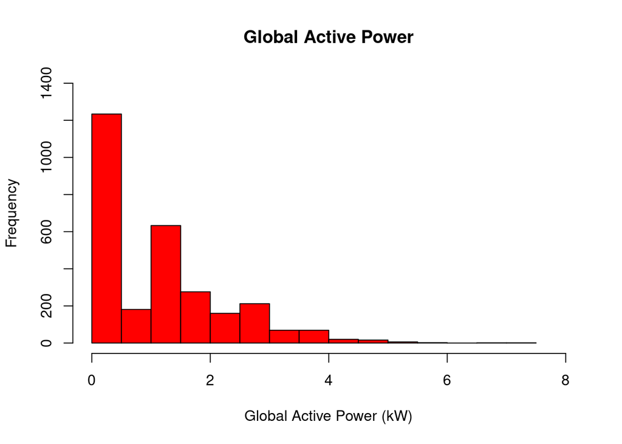

```r
plot_1 <- function(){
    hist(hpc_feb$Global_active_power,
         main = "Global Active Power",
         xlab = "Global Active Power (kW)",
         ylim = c(0, 1400), # Changed x & y limits to read values
         xlim = c(0, 8),
         col = "red")
         # Default for this graphic is width = 480, height = 480.
         # To change the size add the parameters width & height.
}

plot_1()
```

```r
png(file = "mcc_plot_1.png")
plot_1()
dev.off()
```

### Plot 2 - `mcc_plot_2.png`

Plot `Global_active_power` versus `datetime`

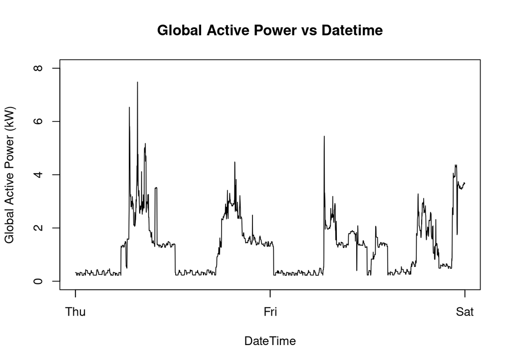

```r
plot_2 <- function(){
    plot(x = hpc_feb$DateTime,
         y = hpc_feb$Global_active_power,
         type = "l",
         main = "Global Active Power vs Datetime",
         ylim = c(0, 8),
         ylab = "Global Active Power (kW)",
         xlab = "DateTime")
         # Default for this graphic is width = 480, height = 480.
         # To change the size add the parameters width & height.
}

plot_2()
```

```r
png(file = "mcc_plot_2.png")
plot_2()
dev.off()
```

### Plot 3 - `mcc_plot_3.png`

Plot of Sub meterings versus datetime

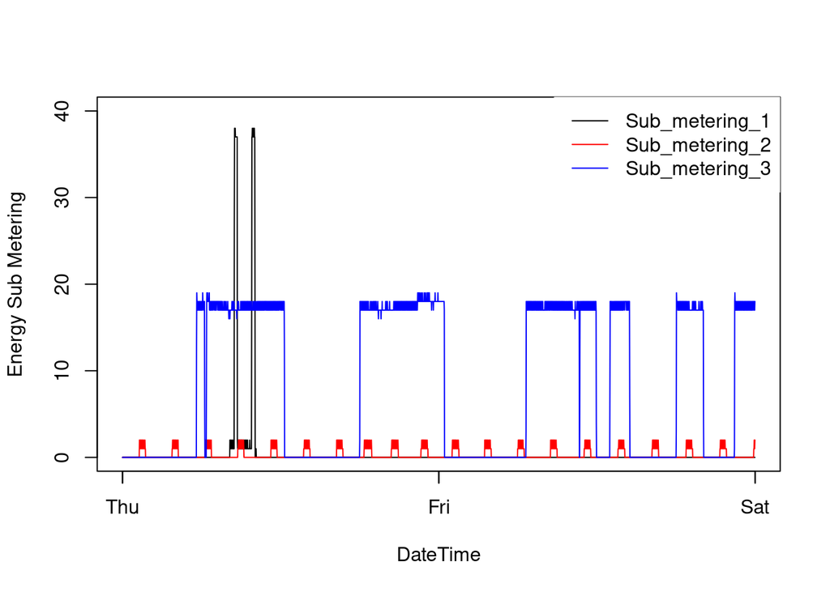

```r
plot_3 <- function(){
    with(hpc_feb, {
         plot(x = DateTime,
         y = Sub_metering_1,
         ylab = "Energy Sub Metering",
         type = "l",
         ylim = c(0, 40))
    lines(x = DateTime,
          y = Sub_metering_2,
          col = "red")
    lines(x = DateTime,
          y = Sub_metering_3,
          col = "blue")
    # add legend
      legend("topright",
             c("Sub_metering_1","Sub_metering_2", "Sub_metering_3"),
             col = c("black", "red", "blue"),
             lty = c(1, 1, 1),
             box.col = "white")
    }
    )
}

plot_3()
```

```r
png(file = "mcc_plot_3.png")
plot_3()
dev.off()
```

### Plot 4 - `mcc_plot_4.png`

**plot_volts**

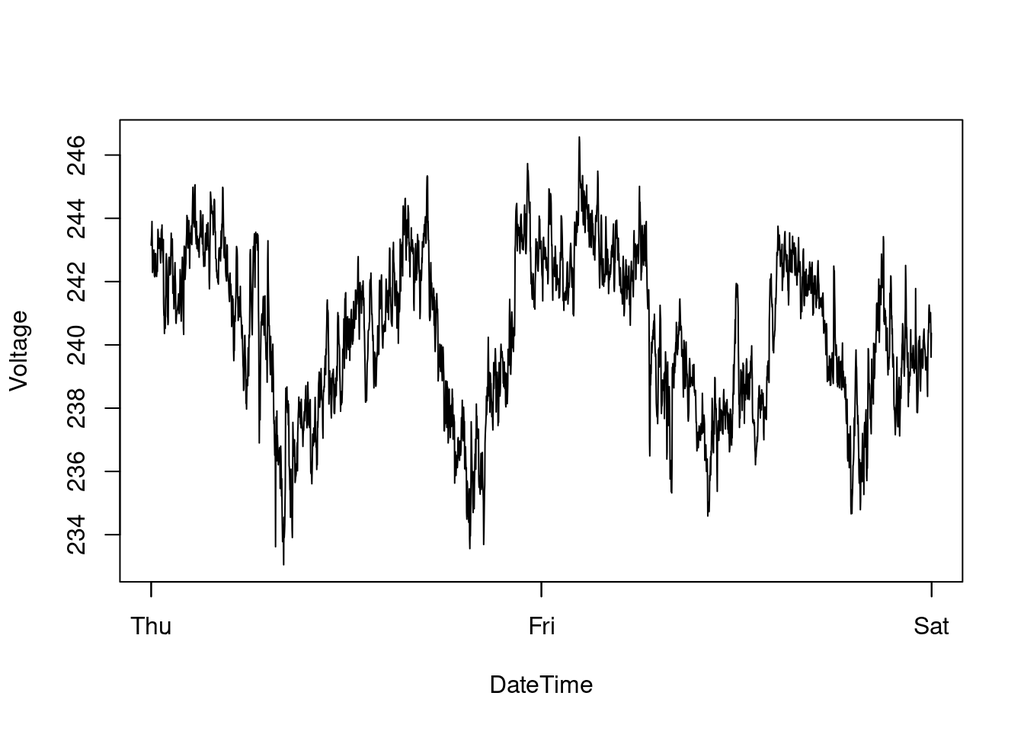

```r
plot_volts <- function(){
      plot(x = hpc_feb$DateTime,
           y = hpc_feb$Voltage,
           xlab = "DateTime",
           ylab = "Voltage",
           type = "l")
}

plot_volts()
```

**plot_grp**

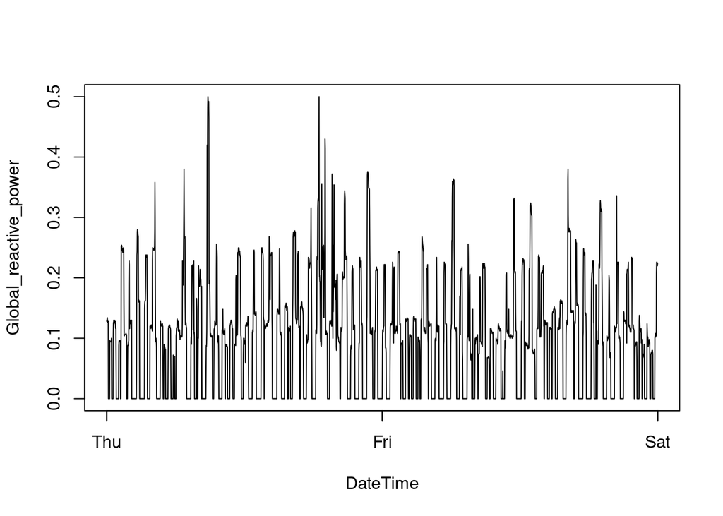

```r
plot_grp <- function(){
      plot(x = hpc_feb$DateTime,
           y = hpc_feb$Global_reactive_power,
           xlab = "DateTime",
           ylab = "Global_reactive_power",
           type = "l")
}

plot_grp()
```

**2 x 2 Plots**

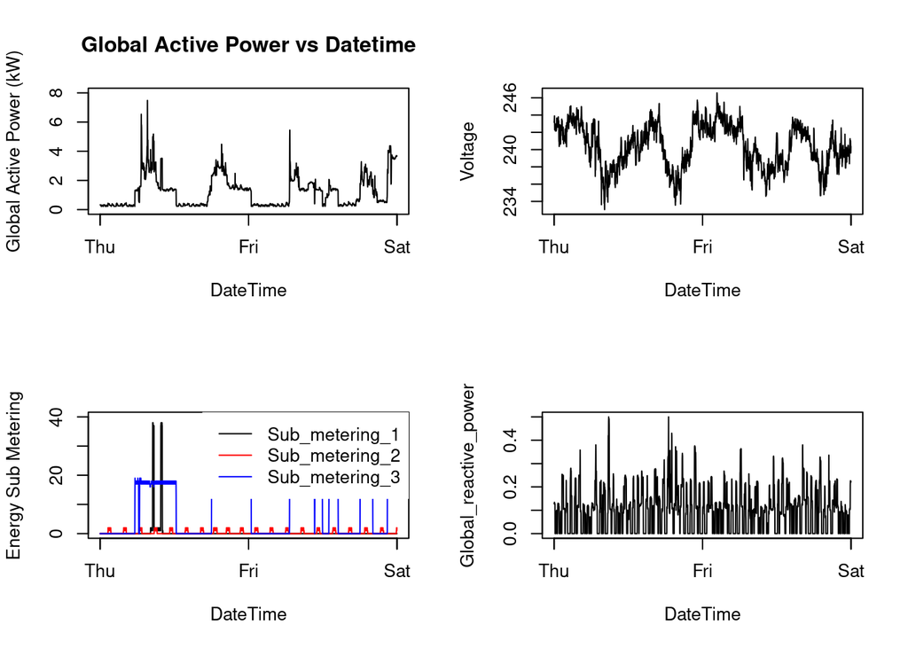

```r
plot_4 <- function(){
    par(mfrow = c(2, 2))
    plot_2()
    plot_volts()
    plot_3()
    plot_grp()
}

plot_4()
```

```r
png(file = "mcc_plot_4.png")
plot_4()
dev.off()
```